# The Science of Decisions Project

## Background Information

In a Stroop task, participants are presented with a list of words, with each word displayed in a color of ink. The participant’s task is to say out loud the color of the ink in which the word is printed. The task has two conditions: a congruent words condition, and an incongruent words condition. In the congruent words condition, the words being displayed are color words whose names match the colors in which they are printed: for example RED, BLUE. In the incongruent words condition, the words displayed are color words whose names do not match the colors in which they are printed: for example PURPLE, ORANGE. In each case, we measure the time it takes to name the ink colors in equally-sized lists. Each participant will go through and record a time from each condition.

```python
# import all necessary packages and functions.
import csv
import numpy as np
import pandas as pd
from scipy import stats
from IPython.display import display
import matplotlib.pyplot as plt
```

```python
# read in the data
tasks_data = pd.read_csv('stroopdata.csv')

# print out the first five rows of the table
display(tasks_data.head(6))
```

|  | Congruent | Incongruent |
| --- | --- | --- |
| 0 | 12.079 | 19.278 |
| 1 | 16.791 | 18.741 |
| 2 | 9.564 | 21.214 |
| 3 | 8.630 | 15.687 |
| 4 | 14.669 | 22.803 |
| 5 | 12.238 | 20.878 |

## Questions For Investigation

**Question 1**: What is our independent variable? What is our dependent variable?

**Answer**:

```
The independent variable is whether the words shown are congruent with the ink colors
or if they are incongruent with ink colors.
The dependent variable is the response time (in seconds) to name the color of the
inks in which the words are displayed.
```

**Question 2**: What is an appropriate set of hypotheses for this task? What kind of statistical test do you expect to perform? Justify your choices.

**Answer**:

```
μC = Mean of the response time of the congruent condition
μI = Mean of the response time of the incongruent condition

H0: μC = μI
    There is no difference in the mean of the response time between the congruent and incongruent condition.
H1: μC ≠ μI
    There is a difference in the mean of the response time between the congruent and incongruent condition.

Statistical test: Dependent sample t-test (two-tailed).
Justifications: First of all, the population mean and standard deviaton are not
                provided, so we should conduct a t-test instead of the z-test.
                Secondly, participants had been tested twice (the congruent and
                incongruent condition), so we should use the dependent sample t-test.
                Thirdly, we want to test whether there is a difference in response
                time between viewing congruent & incongruent words, not whether the
                response time is faster or shorter in viewing congruent words than
                viewing incongruent words. Therefore, we will use the two-tailed
                test.
```

**Question 3**: Report some descriptive statistics regarding this dataset. Include at least one measure of central tendency and at least one measure of variability.

```python
print ("Congruent condition:")
print ("Mean: " + str(round(np.mean(tasks_data.Congruent), 2)))
print ("Median: " + str(round(np.median(tasks_data.Congruent), 2)))
print ("Standard deviation: " + str(round(np.std(tasks_data.Congruent,ddof = 1), 2)))
print ("")
print ("Incongruent condition:")
print ("Mean: " + str(round(np.mean(tasks_data.Incongruent), 2)))
print ("Median: " + str(round(np.median(tasks_data.Incongruent), 2)))
print ("Standard deviation: " + str(round(np.std(tasks_data.Incongruent, ddof = 1), 2)))
```

```
Congruent condition:
Mean: 14.05
Median: 14.36
Standard deviation: 3.56

Incongruent condition:
Mean: 22.02
Median: 21.02
Standard deviation: 4.8
```

**Question 4**: Provide one or two visualizations that show the distribution of the sample data. Write one or two sentences noting what you observe about the plot or plots.

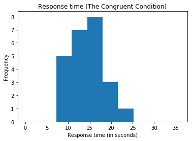

```python
plt.hist(tasks_data.Congruent, range = (0, 36))
plt.xlabel('Response time (in seconds)')
plt.ylabel('Frequency')
plt.title("Response time (The Congruent Condition)")
plt.show()
```

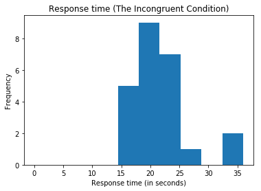

```python
plt.hist(tasks_data.Incongruent, range = (0, 36))
plt.xlabel('Response time (in seconds)')
plt.ylabel('Frequency')
plt.title("Response time (The Incongruent Condition)")
plt.show()
```

**Answer**:

```
The response time is shorter in the congruent condition than incongrugent condition.
```

Now, perform the statistical test and report your results.

```python
stats.ttest_rel(tasks_data.Congruent, tasks_data.Incongruent)
```

```
Ttest_relResult(statistic=-8.020706944109957, pvalue=4.1030005857111781e-08)
```

**Question 5**: What is your confidence level and your critical statistic value? Do you reject the null hypothesis or fail to reject it? Come to a conclusion in terms of the experiment task. Did the results match up with your expectations?

**Answer**:

[output not shown]